# Анализ главных компонент

## Вы сможете

- Найти собственые значения и собственные векторы матрицы и объяснить их смысл.
- Проводить анализ главных компонент при помощи базовых функций R и функций из пакета `vegan`
- Оценивать долю дисперсии, объясненной компонентами
- Снизить размерность данных, оставив небольшое число компонент
- Интерпретировать смысл компонент по их факторным нагрузкам
- Строить ординацию объектов в пространстве главных компонент
- Создавать комплексные переменные и использовать их в других видах анализов

## Постановка задачи для анализа главных компонент

## Зачем нужен анализ главных компонент?

Когда признаков много, можно представить все объекты как облако точек в многомерном пространстве. Обычно в биологических исследованиях признаки объектов взаимозависимы (между ними есть ненулевая ковариация или корреляция).

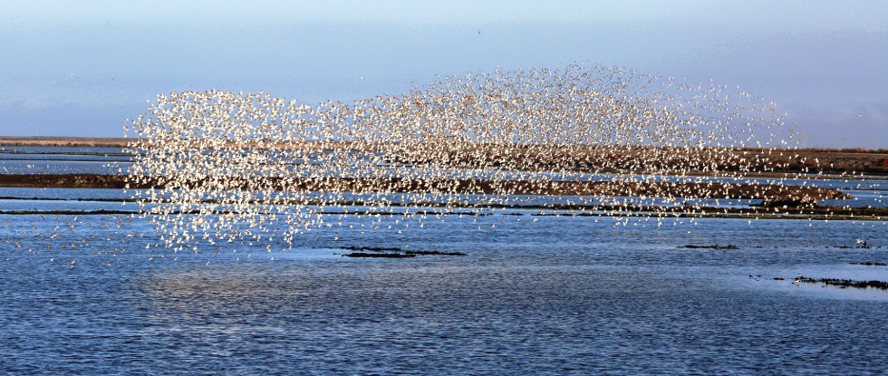

Migration by Don McCullough on [Flickr](https://flic.kr/p/fEFhCj)

## Не все проекции несут важную информацию

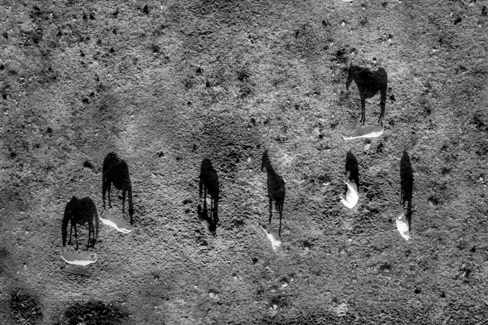

black shadows for a white horses / les negres ombres dels cavalls blancs by Ferran Jordà on [Flickr](https://flic.kr/p/9XJxiL)

## Можно найти оптимальную проекцию, чтобы сохранить максимум информации в минимуме измерений

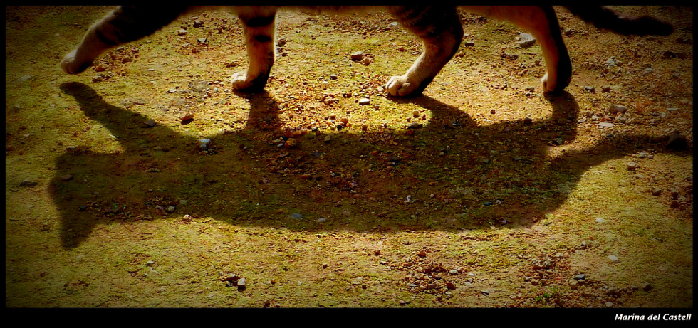

Cat's shadow by Marina del Castell on [Flickr](https://flic.kr/p/ebe5UF)

## Посмотрим, как это выглядит на реальных данных

Данные о размерах медуз *Catostylus mosaicus* (Lunn & McNeil 1991). Медузы собраны в реке Хоксбери (Новый Южный Уэльс, Австралия): часть — на острове Дангар, другая — в заливе Саламандер.

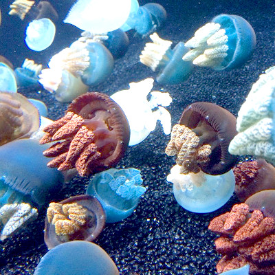

Blubber jellies! by Kirsti Scott on [Flickr](https://flic.kr/p/nWikVp)

[output not shown]

## Двумерные исходные данные

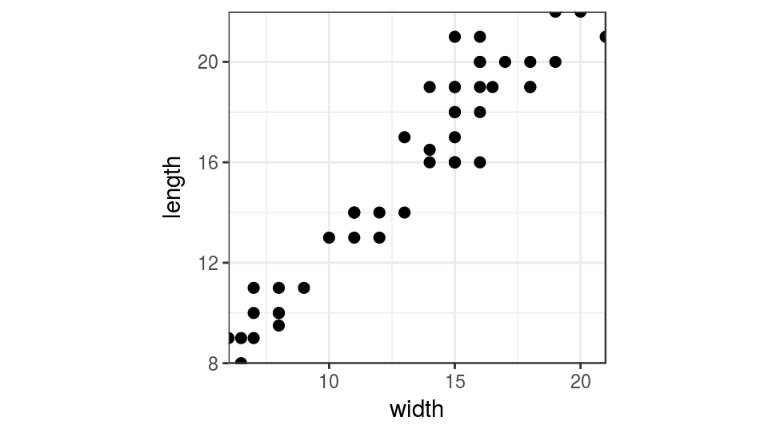

```
##    location width length
## 1         D   6.0    9.0
## 2         D   6.5    8.0
## 3         D   6.5    9.0
## 4         D   7.0    9.0
## 5         D   7.0   10.0
## 6         D   7.0   11.0
## 7         D   8.0    9.5
## 8         D   8.0   10.0
## 9         D   8.0   10.0
## 10        D   8.0   11.0
```

## Задача анализа главных компонент

Исходные переменные скоррелированы. Хочется найти такую трансформацию исходных данных, чтобы "новые" переменные:

- содержали всю исходную информацию
- были независимы друг от друга
- были ранжированы в порядке убывания важности (например, в порядке убывания их дисперсии)

Интуитивно, мы можем добиться этого, если проведем одну ось вдоль направления, в котором максимально вытянуто облако исходных данных. Вторую ось проведем перпендикулярно первой (и они будут независимы).

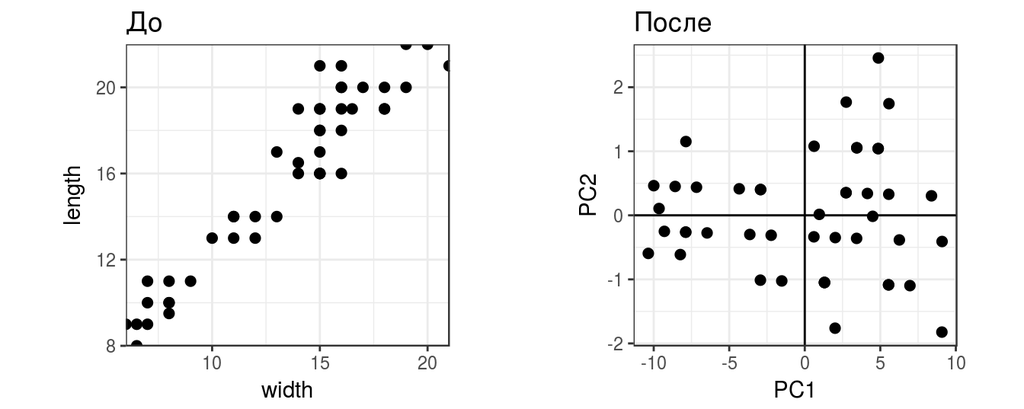

## Анализ главных компонент (Principal Component Analysis, PCA)

PCA позволяет:

- Заменить исходное множество скоррелированных признаков набором синтетических взаимонезависимых переменных (редукция данных, dimension reduction)
- Описать систему взаимосвязей между множеством исходных признаков, ранжировать признаки по важности
- Описать взаимное сходство объектов по многим признакам (ординация объектов)

### Практическое использование PCA

- снижение размерности многомерных данных
- визуализация системы связей между признаками
- сжатие изображений
- распознавание лиц
- анализ формы (геометрическая морфометрия)
- создание синтетических взаимонезависимых признаков для других анализов (например, для регрессии, дискриминантного анализа)

## PCA в матричном виде

## Задача PCA на языке матриц

Нам необходимо найти такую матрицу \(P\), которая позволит вместо \(\mathbf{X}\) взаимозависимых признаков получить \(\mathbf{Y}\) взаимонезависимых признаков.

\[\mathbf{Y} = \mathbf{X}\mathbf{P}\]

Как математически выражается взаимонезависимость?

## Задача PCA на языке матриц

Нам необходимо найти такую матрицу \(P\), которая позволит вместо \(\mathbf{X}\) взаимозависимых признаков получить \(\mathbf{Y}\) взаимонезависимых признаков.

\[\mathbf{Y} = \mathbf{X}\mathbf{P}\]

- Для независимых признаков ковариационная матрица \(cov(\mathbf{Y}) = cov(\mathbf{X}\mathbf{P})\) — диагональная матрица, выше и ниже диагонали нули. Числа на диагонали — дисперсии — упорядочены в порядке убывания.

Как нам выбрать \(\mathbf{P}\)?

- Если исходные данные \(\mathbf{X}\) центрированы, то \(\mathbf{A} = cov(X) = \frac{1}{n - 1} \mathbf{X}\mathbf{X'}\) — это симметричная квадратная матрица.
- Для симметричных квадратных матриц должно существовать спектральное разложение \(\mathbf{A} = \mathbf{E \Lambda E'}\).
- **Если использовать \(\mathbf{P} = \mathbf{E}\) — матрицу собственных векторов для \(\mathbf{A}\), то ковариационная матрица \(cov(\mathbf{X}\mathbf{P})\) будет обладать нужными нам свойствами**.

## Как работает PCA?

1. Исходные данные предварительно центрируют \(\mathbf{X}\)
2. Из \(\mathbf{X}\) получают матрицу \(\mathbf{A} = \frac{1}{n - 1}\mathbf{X}\mathbf{X'}\)
3. После спектрального разложения \(\mathbf{A} = \mathbf{E \Lambda E'}\) получают матрицы собственных векторов \(\mathbf{E}\) и собственных чисел \(\mathbf{\Lambda}\)

### Результаты работы PCA

- **Факторные нагрузки** \(\mathbf{E}\) — собственные векторы, задают направление новых осей
- **Факторные координаты** — новые координаты в пространстве главных компонент \(\mathbf{Y} = \mathbf{X}\mathbf{E}\)
- **Собственные числа** \(\mathbf{\Lambda}\) — оценивают дисперсию вдоль главных компонент

## Еще раз повторим свойства собственных векторов:

- Собственные векторы и собственные числа есть только у некоторых квадратных матриц
- У матрицы \(n \times n\) будет *n* собственных векторов
- Собственные векторы перпендикулярны друг другу (ортогональны)
- **Собственные векторы задают направления в пространстве, вдоль которых дисперсия максимальна**
- Первый собственный вектор, связан с первым собственным числом (максимальное значение \(\lambda_i\)), соответствует максимальной дисперсии, второй - чуть меньшей и т.д.

## PCA вручную

## Сделаем PCA вручную

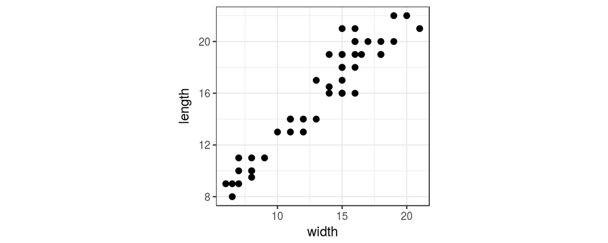

```r
# Исходные данные
jelly <- read.delim("data/jellyfish.csv")

X_raw <- jelly[, 2:3]

gg <- ggplot(as.data.frame(X_raw), aes(x = width, y = length)) +
  geom_point(size = 2) +
  coord_equal()
gg
```

## Центрируем исходные данные

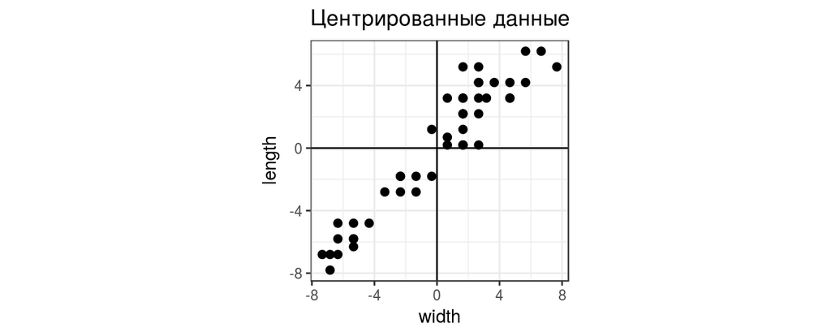

```r
# Центрируем
X <- scale(X_raw, center = TRUE, scale = FALSE)

# График центрированных данных
gg_centered <- gg %+% as.data.frame(X) +
  geom_hline(yintercept = 0) +
  geom_vline(xintercept = 0) +
  coord_equal() +
  ggtitle("Центрированные данные")
gg_centered
```

## PCA

```r
A <- cov(X)    # Матрица ковариаций
E <- eigen(A)  # Спектральное разложение
E$vectors      # Собственные векторы
```

```
##       [,1]   [,2]
## [1,] 0.701 -0.713
## [2,] 0.713  0.701
```

```r
E$values       # Собственные числа
```

```
## [1] 33.339  0.844
```

```r
# Доля объясненной изменчивости
E$values/sum(E$values)
```

```
## [1] 0.9753 0.0247
```

```r
# Факторные координаты (координаты точек в новом пространстве)
Y <- X %*% E$vectors
```

## Ординация точек в пространстве главных компонент

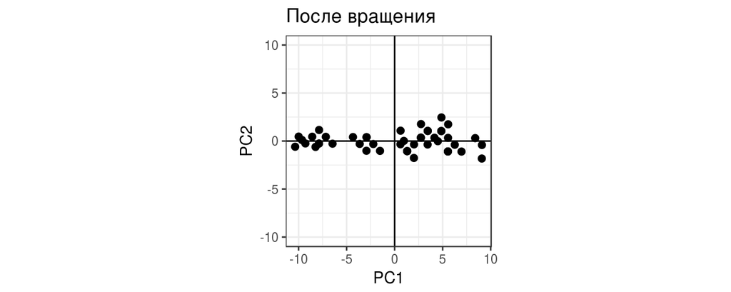

```r
gg_rotated <- gg %+% as.data.frame(Y) +
  aes(x = V1, y = V2) +
  geom_hline(yintercept = 0) +
  geom_vline(xintercept = 0) +
  coord_equal(ylim = c(-10, 10)) +
  labs(title = "После вращения", x = "PC1", y = "PC2")
gg_rotated
```

## Медузы упорядочились по размеру

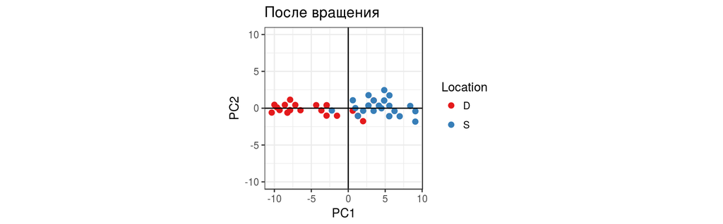

- PC1 — больше всего изменчивости
- PC2 — то, что осталось

## Новые наблюдения на ординаци

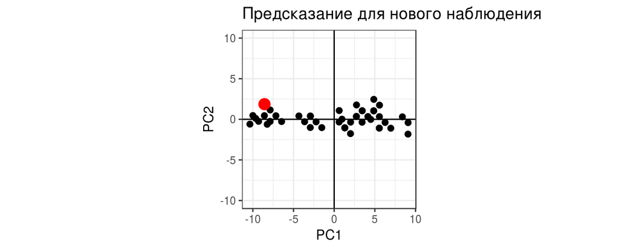

```r
new_raw <- as.matrix(data.frame(width = 6, length = 11))
new_cent <- (new_raw - colMeans(X_raw)) # Центрируем
# Факторные координаты (координаты точек в новом пространстве)
new_y <- new_cent %*% E$vectors

gg_rotated + geom_point(data = data.frame(new_y),
                        aes(x = X1, y = X2), colour = "red") +
  labs(title = "Предсказание для нового наблюдения")
```

## Восстановление исходных данных и их редукция

## Можно восстановить исходные данные

Мы видели, что матрица факторных координат \(\mathbf{Y} = \mathbf{XE}\)

\(\mathbf{\hat{X}} = \mathbf{YE'} = \mathbf{XEE'}\)

Матрица \(\mathbf{EE'}\) называется **проекционной матрицей**

- Если мы используем все собственные векторы, то  
  \(\mathbf{EE'} = \mathbf{I}\),  
  \(\mathbf{\hat{X}} = \mathbf{X}\)
- Если используем только часть, то  
  \(\mathbf{EE'} \ne \mathbf{I}\),  
  \(\mathbf{\hat{X}} \ne \mathbf{X}\)

## Восстанавливаем **полные** исходные данные

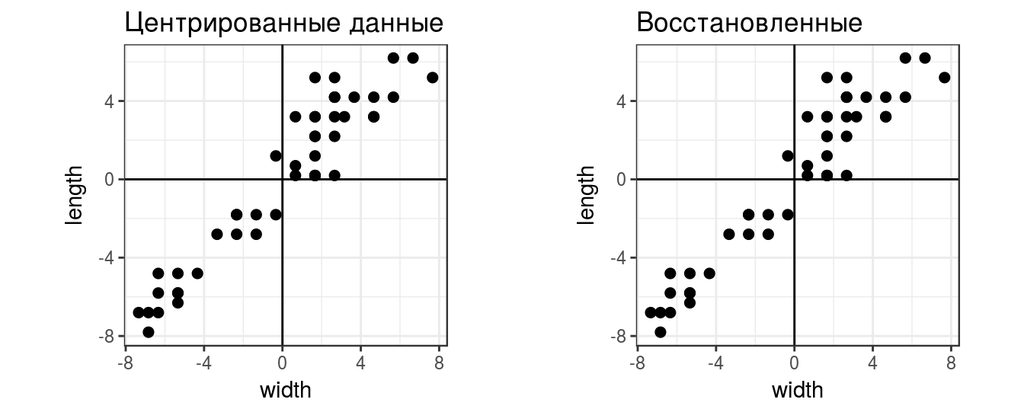

```r
X_back_full <- X %*% E$vectors %*% t(E$vectors)

gg_back_full <- gg_centered %+%
  as.data.frame(X_back_full) +
  aes(x = V1, y = V2) +
  labs(x = "width", y = "length")

library(cowplot)
plot_grid(gg_centered,
          gg_back_full + ggtitle("Восстановленные"),
          align = "h")
```

```r
#
```

## Восстанавливаем **неполные** исходные данные

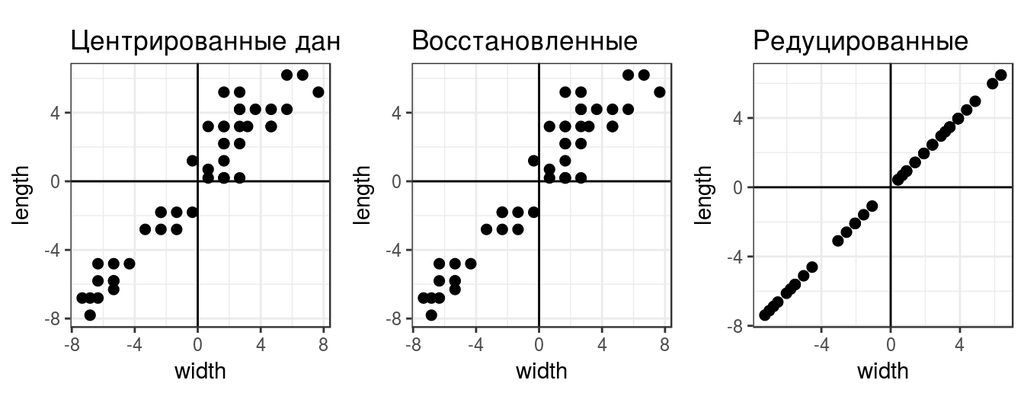

```r
X_back_pc1 <- X %*% E$vectors[, 1] %*% t(E$vectors[, 1]) # только PC1
gg_back_pc1 <- gg_centered %+% as.data.frame(X_back_pc1) +
  aes(x = V1, y = V2) +
  labs(x = "width", y = "length")

plot_grid(gg_centered, gg_back_full + ggtitle("Восстановленные"),
          gg_back_pc1 + ggtitle("Редуцированные"),nrow = 1, align = "h")
```

## PCA и SVD

## Сейчас PCA обычно делают при помощи SVD

Пусть \(\mathbf{A} = \mathbf{E \Lambda E'}\) (спектральное разложение), и \(\mathbf{X} = \mathbf{UDV'}\) (сингулярное разложение)

Если \(\mathbf{Х}\) — матрица центрированных данных, то тогда  
\[\begin{align}\mathbf{A} & = \frac{1}{n - 1}\mathbf{XX'} = \\ & = \frac{1}{n - 1}\mathbf{X'X} = \\ & = \frac{1}{n - 1}\mathbf{(UDV')'UDV'} = \\ & = \frac{1}{n - 1}\mathbf{VDU'UDV'} = \\ & = \frac{1}{n - 1}\mathbf{V D^2 V'}\end{align}\]

- Т.е.  
  \(\mathbf{V} = \mathbf{E}\) — собственные векторы  
  \(\mathbf{D}^2/{(n - 1)} = \mathbf{\Lambda}\) — собственные числа.

## Можно найти главные компоненты при помощи SVD:

\[\begin{align}\mathbf{Y} & = \mathbf{XE} = \\ & = \mathbf{UDV'V} = \\ & = \mathbf{UD}\end{align}\]

Более того, можно сказать, что PCA это частный случай SVD для центрированной матрицы исходных данных.

## Действительно многомерные данные

## Пример: Потребление белков в странах Европы с разными видами продуктов питания

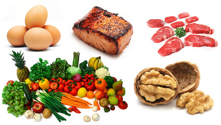

Paleo Diet by zsoolt on [Flickr](https://flic.kr/p/pPK1nz)

Данные из Weber, 1973

## Открываем данные

```r
protein <- read.table(file="data/protein.csv", sep="\t", dec=".", header=TRUE)
protein$region <- factor(protein$region)
rownames(protein) <- protein$country
head(protein)
```

```
##    country      region redmeat whitemeat eggs milk fish cereals
## Al      Al     Balkans    10.1       1.4  0.5  8.9  0.2    42.3
## At      At    W Europe     8.9      14.0  4.3 19.9  2.1    28.0
## Be      Be    W Europe    13.5       9.3  4.1 17.5  4.5    26.6
## Bu      Bu     Balkans     7.8       6.0  1.6  8.3  1.2    56.7
## Cz      Cz    E Europe     9.7      11.4  2.8 12.5  2.0    34.3
## Dk      Dk Scandinavia    10.6      10.8  3.7 25.0  9.9    21.9
##    starch nuts frveg
## Al    0.6  5.5   1.7
## At    3.6  1.3   4.3
## Be    5.7  2.1   4.0
## Bu    1.1  3.7   4.2
## Cz    5.0  1.1   4.0
## Dk    4.8  0.7   2.4
```

Данные из Weber, 1973

## Задание

- Постройте ординацию стран при помощи nMDS с использованием евклидова расстояния
- Постройте график ординации
- Нанесите при помощи envfit векторы изменения исходных переменных

## Решение

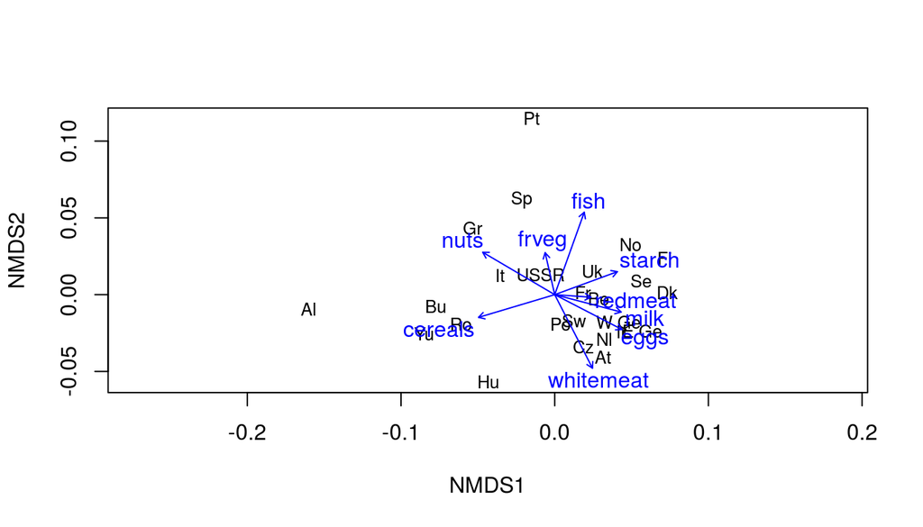

```r
library(vegan)
ord_nmds <- metaMDS(protein[, 3:ncol(protein)],
                    distance = "euclidean",
                    trace = 0)
ef <- envfit(ord_nmds, protein[, 3:ncol(protein)])
plot(ord_nmds, display = "site", type = "t", cex = 0.8)
plot(ef)
```

## PCA: сколько компонент нужно оставить?

## Проведем исследование тех же данных с помощью PCA

```
##
## Call:
## rda(X = protein[, -c(1, 2)], scale = TRUE)
##
## Partitioning of correlations:
##               Inertia Proportion
## Total               9          1
## Unconstrained       9          1
##
## Eigenvalues, and their contribution to the correlations
##
## Importance of components:
##                         PC1   PC2   PC3   PC4    PC5    PC6    PC7
## Eigenvalue            4.006 1.635 1.128 0.955 0.4638 0.3251 0.2716
## Proportion Explained  0.445 0.182 0.125 0.106 0.0515 0.0361 0.0302
## Cumulative Proportion 0.445 0.627 0.752 0.858 0.9098 0.9459 0.9761
##                          PC8    PC9
## Eigenvalue            0.1163 0.0991
## Proportion Explained  0.0129 0.0110
## Cumulative Proportion 0.9890 1.0000
##
## Scaling 2 for species and site scores
## * Species are scaled proportional to eigenvalues
## * Sites are unscaled: weighted dispersion equal on all dimensions
## * General scaling constant of scores:  3.83
##
##
## Species scores
##
##              PC1     PC2     PC3      PC4     PC5     PC6
## redmeat   -0.774 -0.0919 -0.4039 -0.80718  0.2804 -0.3351
## whitemeat -0.794 -0.3870  0.8467  0.04619 -0.2612 -0.0882
## eggs      -1.091 -0.0577  0.2464 -0.39101  0.0689  0.2632
## milk      -0.966 -0.3016 -0.5234  0.00414 -0.1744  0.4506
## fish      -0.347  1.0569 -0.4360  0.26964 -0.2524 -0.0997
## cereals    1.120 -0.3815  0.1302  0.00775  0.2073  0.0588
## starch    -0.760  0.5765  0.3298  0.42038  0.6405  0.1076
## nuts       1.075  0.2342 -0.0738 -0.41239  0.1310  0.3257
## frveg      0.282  0.8761  0.5531 -0.57691 -0.2032  0.0864
##
```

[output cut: 14 more lines]

```
## Hu    0.5698 -0.4994  1.41042  0.1741 -0.0476  0.7399
## Ir   -1.0413 -0.4674 -0.01465 -0.3482  1.1655  0.6619
## It    0.5999  0.2442  0.09291 -0.9791 -0.9233  0.2938
## Nl   -0.6417 -0.5581  0.56477  0.1010 -0.8747  0.4083
## No   -0.3811  0.5031 -1.25562  0.9111 -0.4767 -0.0775
## Po   -0.0476  0.3254  1.08667  0.3670 -0.0267  0.8074
## Pt    0.6669  2.6248  0.03215  0.7157 -0.4427 -0.9567
## Ro    1.0778 -0.6847  0.05164  0.4926  0.3643  0.1791
## Sp    0.5129  1.5627  0.37968 -0.2877  0.5928  0.9185
## Se   -0.6387 -0.1269 -0.94342  0.5879 -0.9420  0.0605
## Sw   -0.3567 -0.4596 -0.11366 -0.9374 -0.9548 -0.1238
## Uk   -0.6785 -0.0575 -0.84933 -1.3885  1.2455 -0.1325
## USSR  0.3060 -0.0678 -0.27239  0.7429  1.9183  0.2545
## W Ge -0.8186 -0.1798  0.59240 -0.0871 -0.0785 -0.2758
## Yu    1.4164 -0.6353  0.15182  0.6580  0.4340  0.4857
```

### Собственные векторы и собственные числа

```
Eigenvalues, and their contribution to the correlations

Importance of components:
                         PC1    PC2    PC3    PC4     PC5     PC6  ...
Eigenvalue            4.0064 1.6350 1.1279 0.9547 0.46384 0.32513 ...
Proportion Explained  0.4452 0.1817 0.1253 0.1061 0.05154 0.03613 ...
Cumulative Proportion 0.4452 0.6268 0.7521 0.8582 0.90976 0.94589 ...
```

## Сколько компонент нужно оставить, если мы хотим редуцировать данные?

- Эмпирические правила
  - Объясняют больше чем по Brocken Stick Model.
  - Компоненты у которых соб. число > 1 (правило Кайзера-Гатмана)
  - В сумме объясняют заданный % от общей изменчивости (60-80%) - слишком субъективно
- Это условности!

## График собственных чисел

```r
eigenvals(prot_pca) # собственные числа
```

```
##  PC1  PC2  PC3  PC4  PC5  PC6  PC7  PC8  PC9
## 4.01 1.63 1.13 0.95 0.46 0.33 0.27 0.12 0.10
```

```r
bstick(prot_pca) # ожидаемое по Brocken Stick Model
```

```
##   PC1   PC2   PC3   PC4   PC5   PC6   PC7   PC8   PC9
## 2.829 1.829 1.329 0.996 0.746 0.546 0.379 0.236 0.111
```

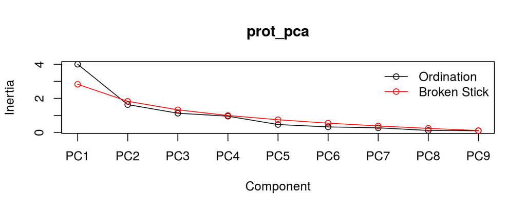

```r
screeplot(prot_pca, type = "lines", bstick = TRUE) # график собственных чисел
```

## Интерпретация компонент

## Интерпретация компонент

Факторные нагрузки оценивают вклады переменных в изменчивость по главной компоненте

- Модуль значения нагрузки - величина вклада
- Знак значения нагрузки - направление вклада

```r
scores(prot_pca, display = "species",
       choices = c(1, 2, 3), scaling = 0)
```

```
##              PC1     PC2     PC3
## redmeat   -0.303 -0.0563 -0.2976
## whitemeat -0.311 -0.2369  0.6239
## eggs      -0.427 -0.0353  0.1815
## milk      -0.378 -0.1846 -0.3857
## fish      -0.136  0.6468 -0.3213
## cereals    0.438 -0.2335  0.0959
## starch    -0.297  0.3528  0.2430
## nuts       0.420  0.1433 -0.0544
## frveg      0.110  0.5362  0.4076
## attr(,"const")
## [1] 3.83
```

### Первая главная компонента:

Высокие **положительные нагрузки по первой главной компоненте** у переменных `cereals` и `nuts`. Значит, чем больше значение первой компоненты, тем больше потребление злаков и орехов.

Высокие **отрицательные нагрузки** у переменных `eggs`, `milk`, `whitemeat`, `redmeat`. Значит, чем меньше значение первой компоненты, тем больше потребление яиц, молока, белого и красного мяса.

- Т.е. первую компоненту можно назвать "Мясо - злаки и орехи"

## Интерпретация компонент

Факторные нагрузки оценивают вклады переменных в изменчивость по главной компоненте

- Модуль значения нагрузки - величина вклада
- Знак значения нагрузки - направление вклада

```r
scores(prot_pca, display = "species",
       choices = c(1, 2, 3), scaling = 0)
```

```
##              PC1     PC2     PC3
## redmeat   -0.303 -0.0563 -0.2976
## whitemeat -0.311 -0.2369  0.6239
## eggs      -0.427 -0.0353  0.1815
## milk      -0.378 -0.1846 -0.3857
## fish      -0.136  0.6468 -0.3213
## cereals    0.438 -0.2335  0.0959
## starch    -0.297  0.3528  0.2430
## nuts       0.420  0.1433 -0.0544
## frveg      0.110  0.5362  0.4076
## attr(,"const")
## [1] 3.83
```

### Вторая главная компонента:

Высокие **положительные нагрузки по второй главной компоненте** у переменных `fish`, `frveg`. Значит, чем больше значение второй компоненты, тем больше потребление рыбы, овощей.

Высоких **отрицательных нагрузкок по второй главной компоненте** нет ни у одной из переменных.

- Т.е. вторую компоненту можно назвать "Потребление рыбы и овощей"

## Графики факторных нагрузок и ординации

## Параметр `scaling`

Внимание! Координаты объектов или переменных можно получить в нескольких вариантах, отличающихся масштабом. От этого масштаба будет зависеть интерпретация.

| scaling | Название графика | Масштаб | Расстояния между объектами | Углы между векторами |
| --- | --- | --- | --- | --- |
| 1, sites | биплот расстояний | координаты объектов масштабированы (х корень из соб. чисел) | апроксимируют евклидовы | нет смысла |
| 2, species | биплот корреляций | координаты признаков масштабированы (х корень из соб. чисел) | НЕ апроксимируют евклидовы | отражают корреляции |
| 3, symmetric |  | масштабированы координаты объектов и признаков (х корень 4-й степени из соб. чисел) |  |  |
| 0, none |  | нет масштабирования |  |  |

## Графики

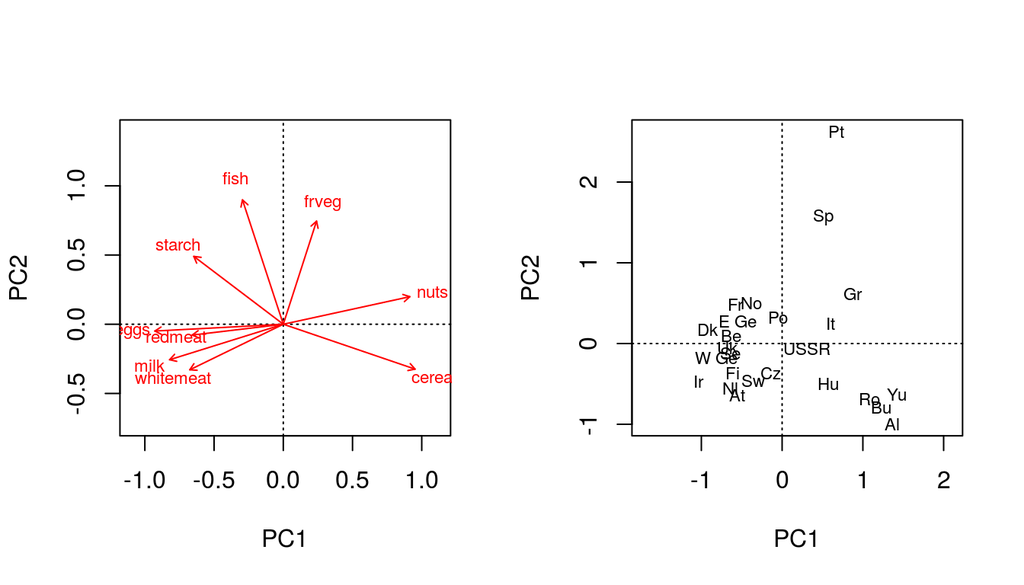

```r
op <- par(mfrow = c(1, 2))
# График факторных нагрузок
biplot(prot_pca, display = "species", scaling = 2)
# График факторных координат
biplot(prot_pca, display = "sites")
par(op)
```

## Те же самые графики можно построить в ggplot

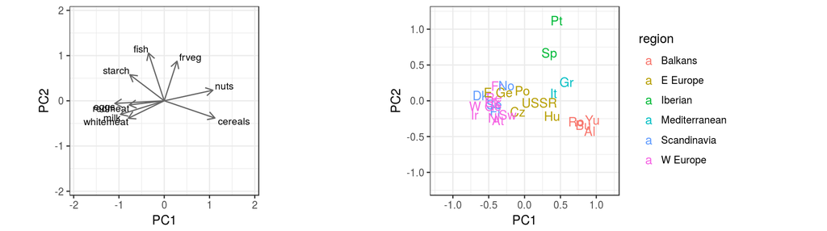

## Исходный код графика нагрузок

```r
df_load <- as.data.frame(scores(prot_pca, display = "species",
                                choices = c(1, 2, 3), scaling = 2))
# поправки для размещения подписей
df_load$hjust[df_load$PC1 >= 0] <- -0.1
df_load$hjust[df_load$PC1 < 0] <- 1
df_load$vjust[df_load$PC2 >= 0] <- -0.1
df_load$vjust[df_load$PC2 < 0] <- 1
library(grid) # для стрелочек
ar <- arrow(length = unit(0.25, "cm"))

p_load <- ggplot(df_load) +
  geom_text(aes(x = PC1, y = PC2, label = rownames(df_load)),
            size = 3, vjust = df_load$vjust, hjust = df_load$hjust) +
  geom_segment(aes(x = 0, y = 0, xend = PC1, yend = PC2),
               colour = "grey40", arrow = ar) +
  coord_equal(xlim = c(-1.9, 1.9), ylim = c(-1.9, 1.9))
```

## Исходный код графика ординации

```r
## График ординации в ggplot
df_scores <- data.frame(protein[, 1:2],
  scores(prot_pca, display = "sites", choices = c(1, 2, 3), scaling = 1))

p_scores <- ggplot(df_scores, aes(x = PC1, y = PC2, colour = region)) +
  geom_text(aes(label = country)) +
  coord_equal(xlim = c(-1.2, 1.2), ylim = c(-1.2, 1.2))
```

## PCA и nMDS

## В данном случае, результаты PCA похожи на nMDS

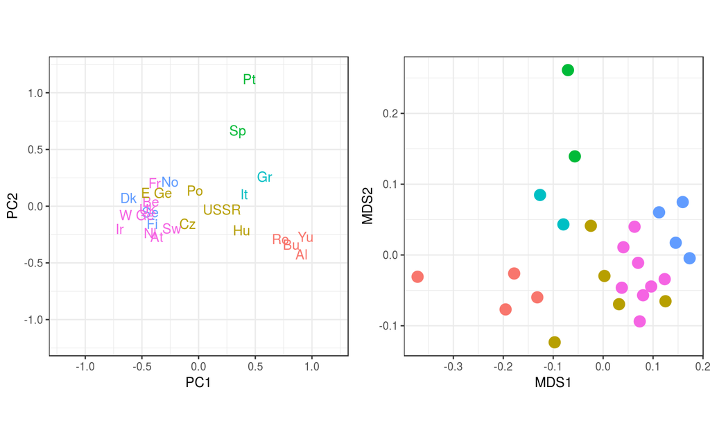

## Создание комплексных переменных при помощи PCA

## Создание комплексных переменных

Факторные координаты - это новые составные признаки, которых можно использовать вместо исходных переменных

Свойства факторных координат:

- Среднее = 0, Дисперсия = 1
- Не коррелируют друг с другом

Применение:

- Уменьшение числа зависимых переменных - для дисперсионного анализа
- Уменьшение числа предикторов - во множественной регрессии

```
##        PC1     PC2     PC3
## Al  0.9091 -0.4253 -0.4594
## At -0.3711 -0.2716  0.3490
## Be -0.4231  0.0416  0.0565
## Bu  0.8175 -0.3394  0.0395
## Cz -0.0966 -0.1572  0.3120
## Dk -0.6170  0.0745 -0.1962
```

## При помощи дисперсионного анализа можно проверить, различается ли значение первой главной компоненты ("Мясо - злаки и орехи") между разными регионами Европы

```r
# Значения факторов (= факторные координаты)
df <- data.frame(region = protein$region,
  scores(prot_pca, display = "sites", choices = c(1, 2, 3), scaling = 1))
mod <- lm(PC1 ~ region, data = df)
anova(mod)
```

```
## Analysis of Variance Table
##
## Response: PC1
##           Df Sum Sq Mean Sq F value       Pr(>F)
## region     5   5.97    1.19    39.3 0.0000000022 ***
## Residuals 19   0.58    0.03
## ---
## Signif. codes:  0 '***' 0.001 '**' 0.01 '*' 0.05 '.' 0.1 ' ' 1
```

- Регионы Европы различаются по потреблению мяса, злаков и орехов

## Проверка условий применимости дисперсионного анализа

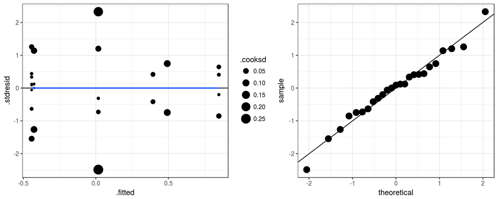

- Условия применимости дисперсионного анализа выполняются

## График значений первой компоненты по регионам

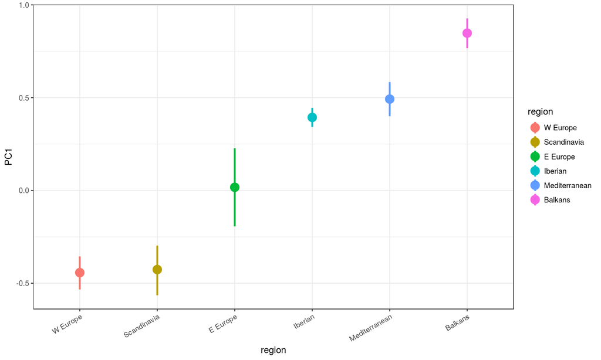

## Пост-хок тест

```r
TukeyHSD(aov(mod))
```

```
##   Tukey multiple comparisons of means
##     95% family-wise confidence level
##
## Fit: aov(formula = mod)
##
## $region
##                              diff     lwr     upr p adj
## E Europe-Balkans          -0.8307 -1.2001 -0.4614 0.000
## Iberian-Balkans           -0.4541 -0.9309  0.0227 0.067
## Mediterranean-Balkans     -0.3555 -0.8323  0.1214 0.221
## Scandinavia-Balkans       -1.2740 -1.6633 -0.8847 0.000
## W Europe-Balkans          -1.2905 -1.6276 -0.9533 0.000
## Iberian-E Europe           0.3766 -0.0840  0.8372 0.150
## Mediterranean-E Europe     0.4753  0.0146  0.9359 0.041
## Scandinavia-E Europe      -0.4433 -0.8126 -0.0740 0.013
## W Europe-E Europe         -0.4597 -0.7736 -0.1459 0.002
## Mediterranean-Iberian      0.0987 -0.4519  0.6492 0.992
## Scandinavia-Iberian       -0.8199 -1.2967 -0.3431 0.000
## W Europe-Iberian          -0.8363 -1.2716 -0.4011 0.000
## Scandinavia-Mediterranean -0.9186 -1.3954 -0.4418 0.000
## W Europe-Mediterranean    -0.9350 -1.3703 -0.4998 0.000
## W Europe-Scandinavia      -0.0164 -0.3536  0.3207 1.000
```

## Summary

- Применение метода главных компонент (PCA):
  - снижение размерности данных
  - исследование связей между переменными
  - построение ординации объектов
  - создание комплексных переменных
- Терминология:
  - Собственные числа - вклад компонент в общую изменчивость
  - Факторные нагрузки - корреляции исходных переменных с компонентами - используются для интерпретации
  - Значения факторов - новые координаты объектов в пространстве уменьшенной размерности

## Что почитать

- Borcard, D., Gillet, F., Legendre, P., 2011. Numerical ecology with R. Springer.
- Legendre, P., Legendre, L., 2012. Numerical ecology. Elsevier.
- Oksanen, J., 2011. Multivariate analysis of ecological communities in R: vegan tutorial. R package version 2–0.
- The Ordination Web Page http://ordination.okstate.edu/ (accessed 05.04.17).
- Quinn, G.G.P., Keough, M.J., 2002. Experimental design and data analysis for biologists. Cambridge University Press.
- Zuur, A.F., Ieno, E.N., Smith, G.M., 2007. Analysing ecological data. Springer.